# Bible Names

## Complex Network Analysis

### 2020 UB - Master's Degree in Data Science

- Christopher Fady
- Xavier López

# Bible Names Network Analysis

This undirected network contains nouns (places and names) of the King James Version of the Bible and information about their co-occurrences.

A node represents one of the above noun types and an edge indicates that two nouns appeared together in the same Bible verse. The edge multiplicity denotes how often two nouns occured together.

http://konect.uni-koblenz.de/networks/moreno_names

## Dataset Overview

- The network is **undirected** and **weighted**.
- The weight is the umber of *word co-ocurrences*

```python
edges = pd.read_csv("data/data.csv",header = None)
edges.columns = ["name1", "name2", "weight"]
edges.head(10)
```

|  | name1 | name2 | weight |
| --- | --- | --- | --- |
| 0 | israel | judah | 100 |
| 1 | jerusalem | judah | 78 |
| 2 | david | israel | 73 |
| 3 | david | saul | 67 |
| 4 | israel | moses | 67 |
| 5 | aaron | moses | 66 |
| 6 | israel | jerusalem | 54 |
| 7 | christ | jesus | 52 |
| 8 | egypt | israel | 40 |
| 9 | abraham | isaac | 34 |

73% of the edges have weight = 1

```python
edges[edges["weight"]==1].shape[0]/edges.shape[0]
```

```
0.7262074252546271
```

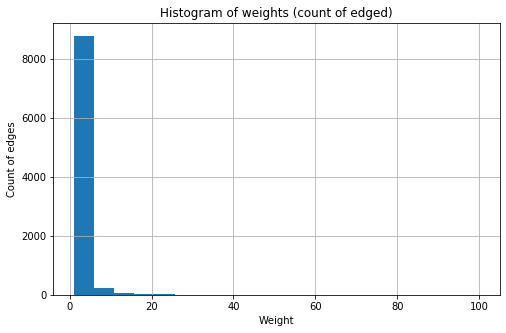

```python
plt.figure(figsize=[8, 5])
hist = edges["weight"].hist(bins=20)
plt.title('Histogram of weights (count of edged)')
plt.xlabel('Weight')
plt.ylabel('Count of edges')
plt.show()
```

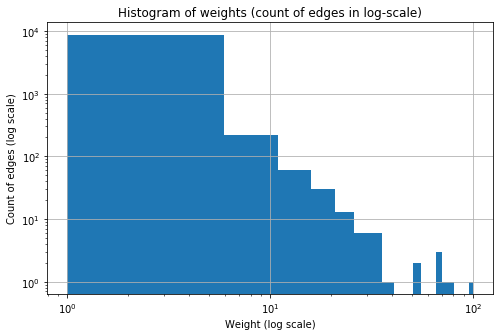

```python
plt.figure(figsize=[8, 5])
hist = edges["weight"].hist(bins=20)
plt.title('Histogram of weights (count of edges in log-scale)')
plt.yscale('log')
plt.xscale('log')
plt.xlabel('Weight (log scale)')
plt.ylabel('Count of edges (log scale)')
plt.show()
```

Since in the log-log histogram can be fit by a line, it is reasonable to say that the weight distribution follows a Power Law.

## Cut Threshold

To avoid losing a lot of data the threshold is set to zero.

```python
th = 0
edges = edges[edges.weight>th]
```

## Location as an attribute

Our nodes can refer to locations or names, to distinguish we created an atribute from external data that categorizes if a node is a location.

```python
df_labs =  pd.read_excel("data/labels.xlsx", sheet_name="Sheet2")
locations = df_labs[df_labs["Location"] == 1]["Node"]
locations = [str(x).replace("'", "").replace(" ", "") for x in locations]

df_labs.head(10)
```

|  | Node | Location |
| --- | --- | --- |
| 0 | israel | True |
| 1 | judah | False |
| 2 | jerusalem | True |
| 3 | david | False |
| 4 | saul | False |
| 5 | moses | False |
| 6 | aaron | False |
| 7 | christ | False |
| 8 | jesus | False |
| 9 | egypt | True |

## Visualization of the Network

### Visualization of the hole network

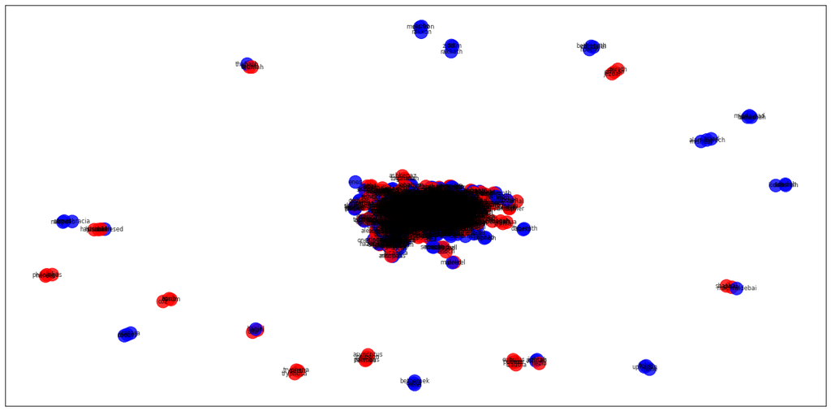

```python
plt.figure(figsize=(20, 10))

nx.draw_networkx(G,node_color = colors, width = 0.5, alpha = 0.8,font_size = 8)
plt.draw()
```

### Visualization of the main connected component

```python
Gc = max(connected_component_subgraphs(G), key=len)
colors = ["blue" if n[1]["location"] else "red" for n in Gc.nodes(data = True)]
pos = nx.spring_layout(Gc)
```

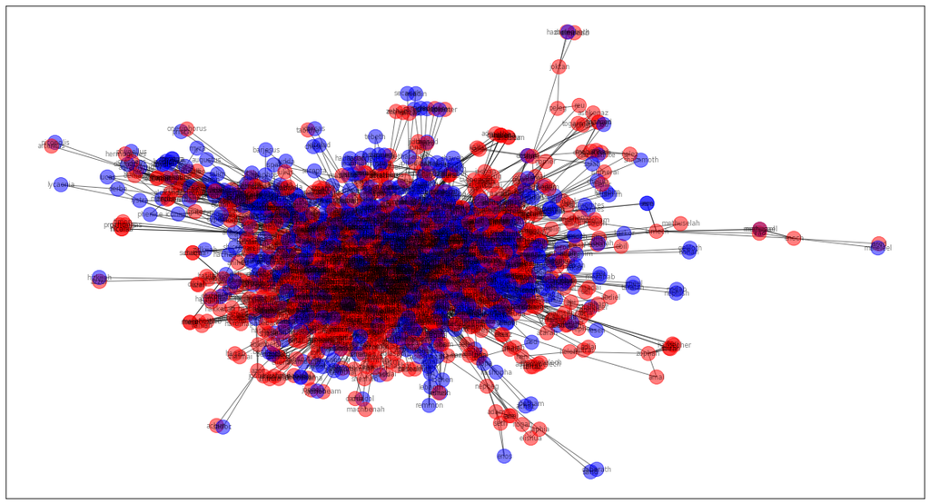

```python
plt.figure(figsize=(20, 11))
nx.draw_networkx(Gc,pos = pos, node_color = colors, alpha = 0.5,font_size = 8)
plt.draw()
```

### Visualization of t he main connected component filtered by location

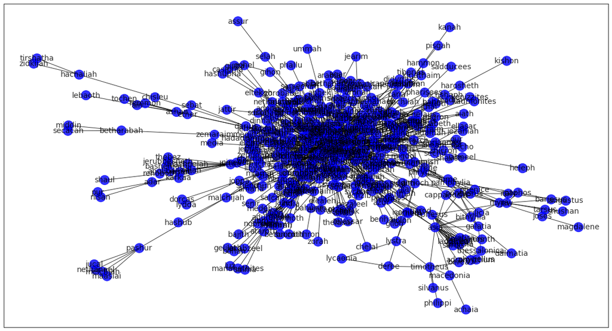

```python
plt.figure(figsize=(20, 11))
nx.draw_networkx(Gcloc, alpha = 0.8,font_size = 14, node_color = colors)
plt.draw()
```

### Visualization of the main connected component filtered by not locations (names)

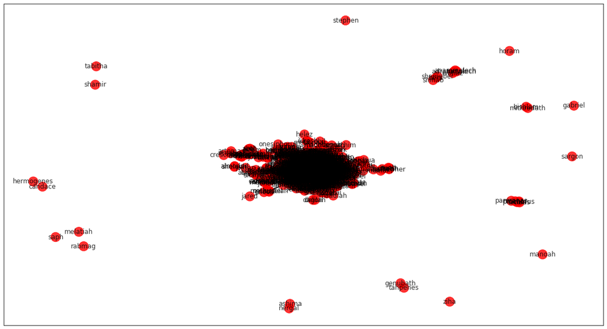

```python
plt.figure(figsize=(20, 11))
nx.draw_networkx(Gc_noloc, alpha = 0.8,font_size = 12, node_color = colors)
plt.draw()
```

### Visualization of the main connected component of the network filtered by names

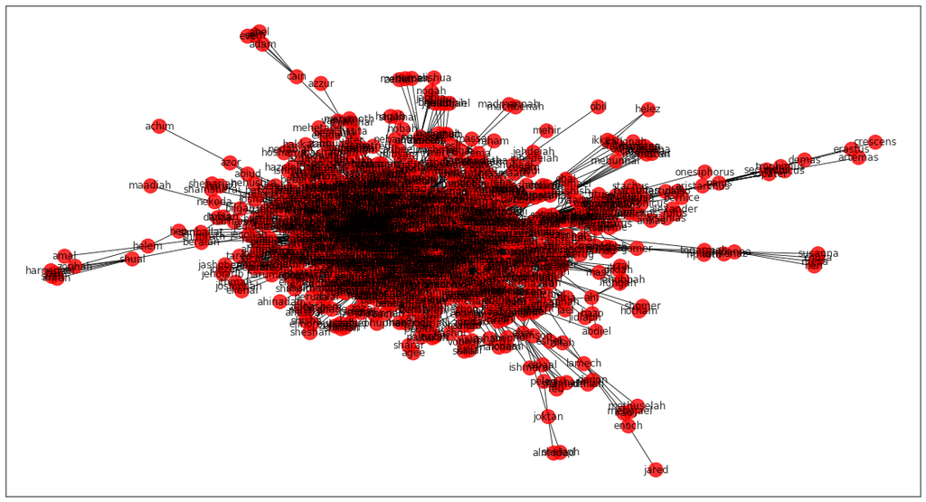

```python
plt.figure(figsize=(20, 11))
nx.draw_networkx(Gc_noloc_cc, alpha = 0.8,font_size = 12, node_color = colors)
plt.draw()
```

## Fundamental Metrics

```python
df
```

|  | Nodes | Edges | Connected Components | density | assortativity |
| --- | --- | --- | --- | --- | --- |
| Entire Network | 1773 | 9131 | 22 | 0.005813 | -0.048850 |
| Main Connected Component | 1707 | 9059 | 1 | 0.006222 | -0.051855 |
| Main cc locations | 419 | 1076 | 1 | 0.012287 | -0.142402 |
| Main cc names | 1077 | 5030 | 20 | 0.008681 | 0.003603 |
| Names main cc | 1046 | 5008 | 1 | 0.009163 | 0.001196 |

- **Density** measures the fraction of existing edges out of all potentially possible edges.
- The most dense network is the network of locations

### Assortativity

```python
df
```

|  | Nodes | Edges | Connected Components | density | assortativity |
| --- | --- | --- | --- | --- | --- |
| Entire Network | 1773 | 9131 | 22 | 0.005813 | -0.048850 |
| Main Connected Component | 1707 | 9059 | 1 | 0.006222 | -0.051855 |
| Main cc locations | 419 | 1076 | 1 | 0.012287 | -0.142402 |
| Main cc names | 1077 | 5030 | 20 | 0.008681 | 0.003603 |
| Names main cc | 1046 | 5008 | 1 | 0.009163 | 0.001196 |

The network is generally disassortative, however filtering we can see that the locations of the network form a dissasortative network and the poeple's names form an assortative net.

- Assortative (high degree tend to be connected with high degree nodes)
- Dissasortative (high degree tend to be connected with low degree).

### Degree Distribution

```python
#Compute degree distribution
df_deg = pd.DataFrame()
df_deg["Node"]= list(G.nodes())
df_deg["degree"] = [G.degree(n) for n in G.nodes()]

#Merge the location category
df_deg = pd.merge(df_labs,df_deg, how='left',left_on = "Node", right_on = "Node")
df_deg["Location"] = df_deg["Location"].map({True: "location", False: "person"})
df_deg = df_deg.rename(columns = {"Location": "type"})

#
df_deg.sort_values( by = ["degree"], ascending = False, inplace = True)
df_deg.head(10)
```

|  | Node | type | degree |
| --- | --- | --- | --- |
| 0 | israel | location | 364 |
| 1 | judah | person | 254 |
| 3 | david | person | 221 |
| 2 | jerusalem | location | 202 |
| 9 | egypt | location | 122 |
| 18 | benjamin | person | 110 |
| 28 | manasseh | person | 108 |
| 26 | ephraim | person | 104 |
| 4 | saul | person | 103 |
| 16 | philistines | location | 100 |

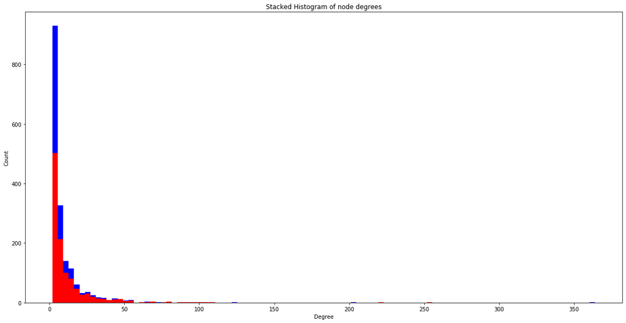

```python
deg_loc = df_deg[df_deg["type"]=="location"]["degree"]
deg_nloc = df_deg[df_deg["type"]!="location"]["degree"]



plt.figure(figsize=[20, 10])
hist = plt.hist([deg_nloc,deg_loc],stacked=True, bins = 100, color = ["r","b"], label = ["1","2"])
plt.title('Stacked Histogram of node degrees')
plt.xlabel('Degree')
plt.ylabel('Count')
plt.show()
```

#### This looks like a Power-law distribution, is it?

Lets do the log-log histograms (if they follow a straight line they will fit a Power-law distribution)

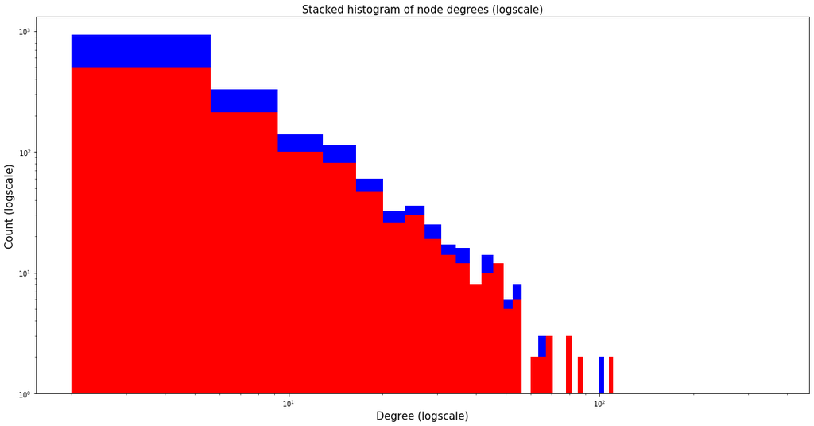

```python
plt.figure(figsize=[20, 10])
hist = plt.hist([ deg_nloc,deg_loc],bins = 100,stacked=True, color = ["r","b"], label = ["1","2"])
plt.title('Stacked histogram of node degrees (logscale)',fontsize=15)
plt.xlabel('Degree (logscale)',fontsize=15)
plt.ylabel('Count (logscale)',fontsize=15)
plt.yscale('log')
plt.xscale('log')
plt.show()
```

A straight line could fit reasonably well this histogram, therefore it is reasonable to assume that the degree distribution follows a **power law**, i.e. our network is **scale-free**.

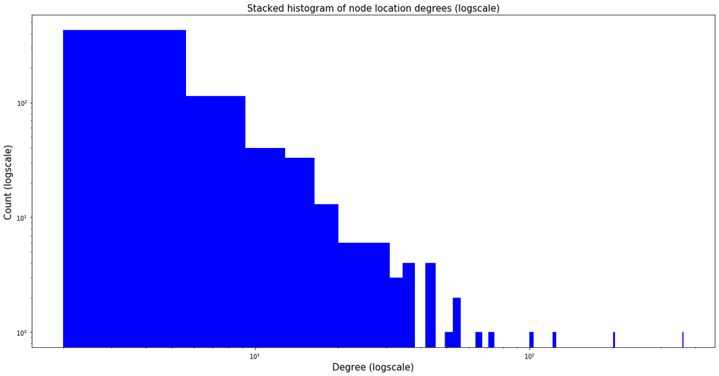

```python
plt.figure(figsize=[20, 10])
hist = plt.hist([deg_loc],bins = 100,stacked=True, color = ["b"], label = ["1","2"])
plt.title('Stacked histogram of node location degrees (logscale)',fontsize = 15)
plt.xlabel('Degree (logscale)',fontsize = 15 )
plt.ylabel('Count (logscale)', fontsize = 15)
plt.yscale('log')
plt.xscale('log')
plt.show()
```

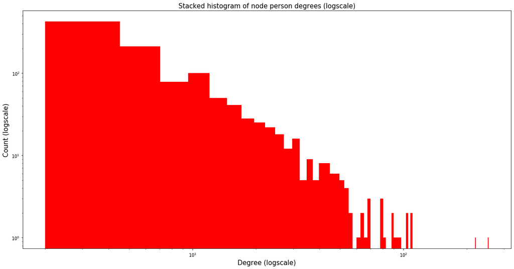

```python
deg_loc = df_deg[df_deg["type"]=="location"]["degree"]
deg_nloc = df_deg[df_deg["type"]!="location"]["degree"]



plt.figure(figsize=[20, 10])
hist = plt.hist([deg_nloc],bins = 100,stacked=True, color = ["r"], label = ["1","2"])
plt.title('Stacked histogram of node person degrees (logscale)', fontsize = 15)
plt.xlabel('Degree (logscale)', fontsize = 15)
plt.ylabel('Count (logscale)', fontsize = 15)
plt.yscale('log')
plt.xscale('log')
plt.show()
```

Top 10 nodes by degree (number of edges conected to the node):

```python
df_deg.head(10)
```

|  | Node | type | degree |
| --- | --- | --- | --- |
| 0 | israel | location | 364 |
| 1 | judah | person | 254 |
| 3 | david | person | 221 |
| 2 | jerusalem | location | 202 |
| 9 | egypt | location | 122 |
| 18 | benjamin | person | 110 |
| 28 | manasseh | person | 108 |
| 26 | ephraim | person | 104 |
| 4 | saul | person | 103 |
| 16 | philistines | location | 100 |

Top 10 **location** nodes by degree (number of edges conected to the node):

```python
df_deg[df_deg["type"] == "location"].head(10)
```

|  | Node | type | degree |
| --- | --- | --- | --- |
| 0 | israel | location | 364 |
| 2 | jerusalem | location | 202 |
| 9 | egypt | location | 122 |
| 16 | philistines | location | 100 |
| 14 | babylon | location | 74 |
| 22 | samaria | location | 66 |
| 53 | assyria | location | 53 |
| 37 | ammon | location | 53 |
| 59 | galilee | location | 50 |
| 17 | sin | location | 44 |

```python
df_deg[df_deg["type"] == "person"].head(20)
```

|  | Node | type | degree |
| --- | --- | --- | --- |
| 1 | judah | person | 254 |
| 3 | david | person | 221 |
| 18 | benjamin | person | 110 |
| 28 | manasseh | person | 108 |
| 26 | ephraim | person | 104 |
| 4 | saul | person | 103 |
| 5 | moses | person | 97 |
| 34 | gilead | person | 93 |
| 33 | joseph | person | 91 |
| 23 | jordan | person | 88 |
| 293 | shemaiah | person | 88 |
| 21 | solomon | person | 81 |
| 36 | moab | person | 80 |
| 291 | maaseiah | person | 79 |
| 103 | azariah | person | 78 |
| 254 | zechariah | person | 70 |
| 106 | canaan | person | 70 |
| 8 | jesus | person | 68 |
| 12 | jacob | person | 65 |
| 41 | hebron | person | 64 |

### Degree-rank plot

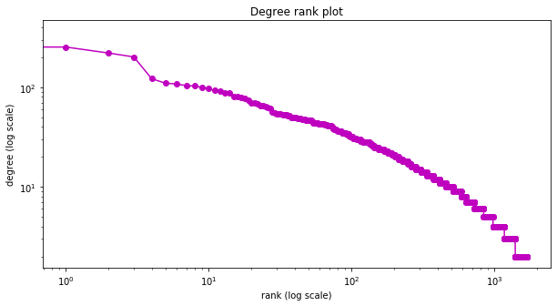

```python
degree_sequence = sorted([d for n, d in Gc.degree()], reverse=True)
dmax = max(degree_sequence)

fig, ax = plt.subplots(figsize=(10, 5))
plt.loglog(degree_sequence, 'm-', marker='o')
plt.title("Degree rank plot")
plt.ylabel("degree (log scale)")
plt.xlabel("rank (log scale)")
plt.show()
```

## Macroscale

### Eccentricity

Eccentricity of a node $v$ is the maximum distance from $v$ to all other nodes in $G$

```python
ec = nx.eccentricity(Gc)
```

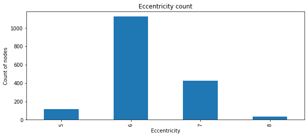

```python
fig, ax = plt.subplots(figsize=(10, 4))
ax = df["eccentricity"].value_counts().sort_index().plot(kind="bar", title = "Eccentricity count")
ax.set_xlabel("Eccentricity")
ax.set_ylabel("Count of nodes")
```

- **diameter**: larges distance between a pair of nodes in the network (maximum eccentricity)

```python
d = nx.diameter(Gc)
d
```

```
8
```

- **radius**: minimum ecentricity

```python
r = nx.radius(Gc)
r
```

```
5
```

- **center**: set of all vertices of minimum eccentricity, i.e. the set of all vertices $u$ where the greatest distance $d(u,v)$ to other vertices is minimal.

```python
c = nx.center(Gc)
len(c)
```

```
119
```

```python
c[0:10]
```

```
['israel',
 'judah',
 'jerusalem',
 'david',
 'saul',
 'moses',
 'aaron',
 'egypt',
 'abraham',
 'isaac']
```

- **periphery**: Set of nodes with eccentricity equal to the diameter, i.e. $d(u,v)$ is maximal.

```python
p = nx.periphery(Gc)
len(p)
```

```
35
```

### Shortest path length

The average shortest path length is the sum of path lengths d(u,v) between all pairs of nodes (assuming the length is zero if v is not reachable from v) normalized by n*(n-1) where n is the number of nodes in G.

```python
spl = nx.average_shortest_path_length(Gc)
spl
```

```
3.3755393796044286
```

```python
np.log(len(Gc.nodes))
```

```
7.442492722794441
```

Our shortest path length is less than half of the standard of a social network (facebook)

$$ L \sim \ln(N) $$

```python
spl/np.log(len(Gc.nodes))
```

```
0.4535495707326686
```

Even the shortest path length of the filtered by person names main connected component has a similar average shortest path length.

```python
nx.average_shortest_path_length(Gc_noloc_cc)
```

```
3.482882157592835
```

### Average neighbour degree:

The average degree of a node is

$$ k_{nn,i} = \frac{1}{|N(i)|} \sum_{j\in N(i)}k_j $$

where $N(i)$ are the neighbors of node $i$ and $k_j$ is the degree of node $j$ which belongs to $N(i)$. (The degree is the number of edges connected to each node).

```python
df_avnd = pd.DataFrame.from_dict(nx.average_neighbor_degree(Gc),orient = "index", columns = ["average_neigh_degree"])
df_avnd
```

|  | average_neigh_degree |
| --- | --- |
| israel | 24.266484 |
| judah | 29.263780 |
| jerusalem | 29.282178 |
| david | 28.742081 |
| saul | 35.572816 |
| ... | ... |
| zephath | 102.666667 |
| berothai | 8.500000 |
| nephish | 4.500000 |
| philippi | 44.500000 |
| hashupha | 7.000000 |

1707 rows × 1 columns

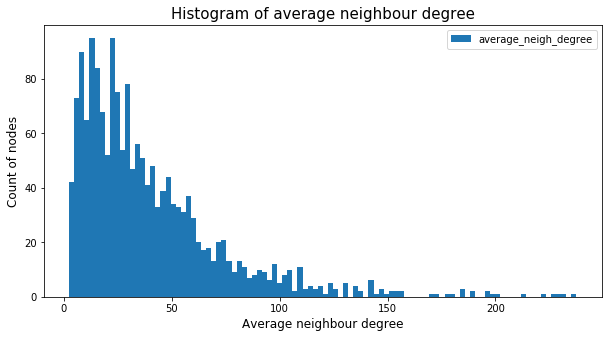

```python
df_avnd.plot.hist(by="average_neigh_degree", bins = 100,figsize = (10,5))
plt.title('Histogram of average neighbour degree', fontsize = 15)
plt.xlabel('Average neighbour degree', fontsize = 12)
plt.ylabel('Count of nodes',fontsize = 12)
```

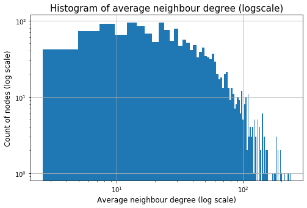

```python
plt.figure(figsize=[8, 5])
hist = df_avnd["average_neigh_degree"].hist(bins=100)
plt.yscale('log')
plt.xscale('log')

plt.title('Histogram of average neighbour degree (logscale)', fontsize = 15)
plt.xlabel('Average neighbour degree (log scale)', fontsize = 12)
plt.ylabel('Count of nodes (log scale)',fontsize = 12)


plt.show()
```

#### Neighbours of Jesus

We all may be sons of Jesus...

But not everyone is a neighbour of Jesus:

```python
jesus = Gc["jesus"]
print(len(jesus))
print(jesus)
```

```
68
{'christ': {'weight': 52}, 'peter': {'weight': 20}, 'paul': {'weight': 15}, 'galilee': {'weight': 14}, 'simon': {'weight': 11}, 'john': {'weight': 9}, 'sin': {'weight': 9}, 'nazareth': {'weight': 8}, 'philip': {'weight': 5}, 'moses': {'weight': 5}, 'israel': {'weight': 5}, 'pilate': {'weight': 5}, '…
```

```python
egypt = Gc["israel"]
print(len(egypt))
print(egypt)
```

```
364
{'judah': {'weight': 100}, 'david': {'weight': 73}, 'moses': {'weight': 67}, 'jerusalem': {'weight': 54}, 'egypt': {'weight': 40}, 'jeroboam': {'weight': 33}, 'saul': {'weight': 31}, 'aaron': {'weight': 31}, 'philistines': {'weight': 27}, 'sin': {'weight': 26}, 'joshua': {'weight': 25}, 'solomon': {…
```

### Clustering Coefficient (not considering weights)

Clustering coefficient: measure of the prevelance of triangles in an egocentric network.

The clustering coefficient is the fraction of possible triangles that contain the given node and exist.

If the clustering coefficient of a node is 1, the **node participates in every possible triangle** involving any pair of its neighours; the egocentric network of such a node is a complete graph. If the clustering coefficient of a node is 0, no two nodes in the neigbourhood are connected; the egocentric network of such a node iss a ster. Think of clustering coefficient as a measure of "stardom"

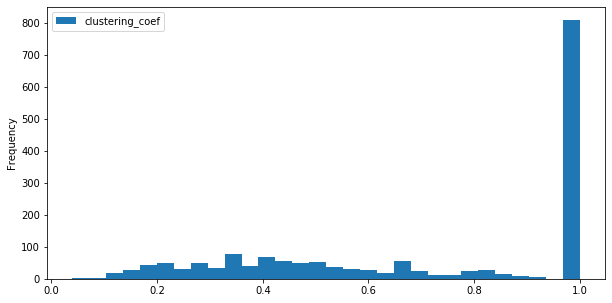

```python
df_cc.plot.hist(by="clustering_coef", bins = 30,figsize = (10,5))
```

### Clusteirng Coefficient distribution considering weights

For weighted graphs, the clustering is defined as the geometric average of the subgraph edge weights

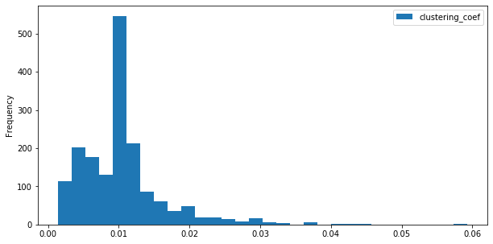

```python
df_cc.plot.hist(by="clustering_coef", bins = 30,figsize = (10,5))
```

### Transitivity

(clustering coefficient of the whole network, i.e. fraction of all possible triangles that exist in the network)

```python
trans = nx.transitivity(Gc); trans
```

```
0.16249612832760055
```

### Number of triangles

```python
df_tri = pd.DataFrame.from_dict(nx.triangles(Gc),orient = "index", columns = ["triangles"])
df_tri
```

|  | triangles |
| --- | --- |
| israel | 2621 |
| judah | 1916 |
| jerusalem | 1232 |
| david | 1459 |
| saul | 565 |
| ... | ... |
| zephath | 3 |
| berothai | 1 |
| nephish | 1 |
| philippi | 6 |
| hashupha | 1 |

1707 rows × 1 columns

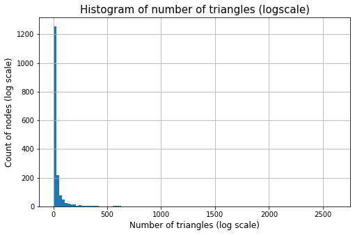

```python
plt.figure(figsize=[8, 5])
hist = df_tri["triangles"].hist(bins=100)

plt.title('Histogram of number of triangles (logscale)', fontsize = 15)
plt.xlabel('Number of triangles (log scale)', fontsize = 12)
plt.ylabel('Count of nodes (log scale)',fontsize = 12)


plt.show()
```

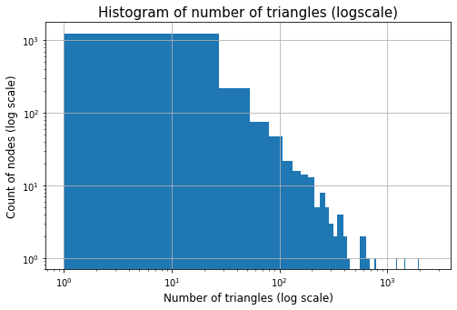

```python
plt.figure(figsize=[8, 5])
hist = df_tri["triangles"].hist(bins=100)
plt.yscale('log')
plt.xscale('log')

plt.title('Histogram of number of triangles (logscale)', fontsize = 15)
plt.xlabel('Number of triangles (log scale)', fontsize = 12)
plt.ylabel('Count of nodes (log scale)',fontsize = 12)


plt.show()
```